[figure not shown]

imagen

# Pruebas de Hipótesis Usando la Distribución Normal

Hemos revisado los conceptos comunes a todas las pruebas de hipótesis en general y mencionado que, en estas pruebas, cuando se refieren a la media, se comparan la media poblacional y la media muestral. A continuación, mostraré cómo establecer la hipótesis nula y la hipótesis alternativa cuando disponemos de información de datos que siguen una distribución normal. En este contexto, el valor de la media muestral será la estadística de prueba.

## ¿Cómo Establecer las Hipótesis?

Para realizar pruebas de hipótesis relacionadas con el valor de la media de la población, necesitaremos tres parámetros que debemos obtener de los datos o que deben estar proporcionados por el problema. Estos son: la media poblacional $\mu$ , la desviación estándar de la población $\sigma$, y la media de la muestra $\overline{x}$. La prueba de hipótesis se realizará para determinar cuál de las dos siguientes opciones es cierta:

1. La media muestral obtenida surgió de manera aleatoria de la muestra, sin ninguna causa externa.
2. La media muestral no surgió de manera aleatoria, indicando que hubo algún factor externo que influyó en ella.

Si asumimos que el valor obtenido experimentalmente de la media poblacional es $\mu_0$. Lo anterior se traduce estadísticamente en la formulación de las hipótesis de la siguiente manera:

- La **hipótesis nula** será que, dadas $\overline{x}$ y $\sigma$, la media poblacional es igual al valor obtenido experimentalmente. Es decir:
  $$H_0:\mu=\mu_0$$
- La **hipótesis alternativa** será que, dadas $\overline{x}$ y $\sigma$, la media de la población no es igual al valor obtenido experimentalmente. Es decir:
  $$H_1:\mu\neq\mu_0$$

### Ejemplo (Fórmulación de las Hipótesis):

El departamento de marketing de una empresa ha lanzado una nueva campaña de publicidad y quiere saber si esta ha afectado de alguna forma las ventas. En el pasado, las ventas promediaron $\$10345$ al día con una desviación estándar de $\$552$. La nueva campaña de publicidad se ejecutó durante $45$ días y el promedio de ventas fue de $\$11641$ por día.

¿La campaña afectó las ventas?

Para solucionar este problema deberemos realizar una prueba de hipótesis, lo primero a hacer es establecer las hipótesis, para ello nótese que el valor de la media poblacional es $\mu_0=10345$, donde los otros dos párametros son la desviación estándar poblacional $\sigma=552$ y la media muestral $\overline{x}=11641$. Así, nuestrashipótesis serán:

$$\begin{align}
H_0 &: \mu=10345 \text{ y}\\
H_1 &: \mu\neq10345.
\end{align}$$

Guardemos nuestros parámetros en las líneas de código de python:

```python
# Establezcamos nuestros parámetros:
media_poblacional = 10345
media_muestral = 11641
desv_std = 552
```

Antes de aplicar el siguiente paso, es importante notar que es imposible estar absolutamente seguros de que alguna de las dos opciones sea completamente verdadera. Sin embargo, lo que sí podemos hacer es, a partir de un nivel de probabilidad que consideremos aceptable, afirmar que una de las opciones es verdadera. Para ello, se establece un nivel de *significancia estadística*, que ya definimos en el artículo anterior sobre pruebas de hipótesis. Lo más común es establecer dicho porcentaje en un $5\%$. Cómo se utiliza este parámetro se entenderá mejor en la siguiente parte.

## Tipos de Prueba

Las pruebas de hipótesis pueden ser unilaterales, lo cual significa que solo se consideran las áreas y puntos críticos de una cola de la curva de la distribución (puede ser la izquierda o la derecha), o bilaterales, en las cuales, en lugar de considerar solo una cola, se divide la significancia estadística en dos y se estudian ambas colas, la derecha y la izquierda.

### Ejemplo (Prueba Bilateral):

Para nuestro problema, no se nos pide diferenciar si los posibles efectos de la campaña de marketing fueron positivos o negativos para las ventas, así que consideraremos ambos. Por lo tanto, la prueba será bilateral. En este caso, asumiendo la significancia estadística más común del $\frac{0.05}{2}$ y $1-\frac{0.05}{2}$, lo que equivale al rango de aceptación de la hipótesis nula en probabilidades, que será $(0.025,0.975)$.

```python
# Establezcamos la significancia y la probabilidad de las colas:
Significancia = 0.05
Cola_Izq_Prob = 0.025
Cola_Der_Prob = 0.975
```

Ahora bien, existen tres métodos para realizar la prueba referente al valor de la media de la población. Estos son los siguientes:

## Método del Valor Crítico

En este método, según el rango de probabilidades establecido anteriormente con base en la significancia estadística, calcularemos los puntos críticos $x_1$ y $x_2$ utilizando la función punto de probabilidad (PPF) que, como mencionamos antes, se determinarán sobre la distribución normal con los parámetros de la población:

$$x_1=F^{-1}(\text{Probabilidad Cola Izquierda };\mu,\sigma)$$
$$x_2=F^{-1}(\text{Probabilidad Cola Derecha };\mu,\sigma)$$

Después de ello, debemos determinar si la media muestral $\overline{x}$ se encuentra dentro o no del rango de los puntos críticos $(x_1,x_2)$. Si ese es el caso y $\overline{x}\in{(x_1,x_2)}$, entonces se acepta la hipótesis nula, de lo contrario se rechaza.

### Ejemplo (Método del Valor Crítico):

Ya que antes establecimos los parámetros, podremos calcular la funcion de punto de probabilidad PPF por medio del módulo SciPy de Python:

```python
# Importamos el paquete necesario:
from scipy.stats import norm

# Calculamos los puntos críticos usando SciPy:
x_1 = norm.ppf(Cola_Izq_Prob, media_poblacional, desv_std).round(4)
x_2 = norm.ppf(Cola_Der_Prob, media_poblacional, desv_std).round(4)
print(f"Los valores críticos son x_1={x_1} y x_2={x_2}")

# Veríficamos si la media muestral esta dentro o no del rango de los puntos críticos, para rechazar o aceptar H_0:
if media_muestral >= x_1 and media_muestral <= x_2:
  print('No puede rechazar la hipótesis nula H_0.')
else:
  print('Se puede rechazar la hipótesis nula H_0.')
```

```
Los valores críticos son x_1=9263.0999 y x_2=11426.9001
Se puede rechazar la hipótesis nula H_0.
```

Debido a la naturaleza de las pruebas estadísticas, podremos observar este resultado gráficamente:

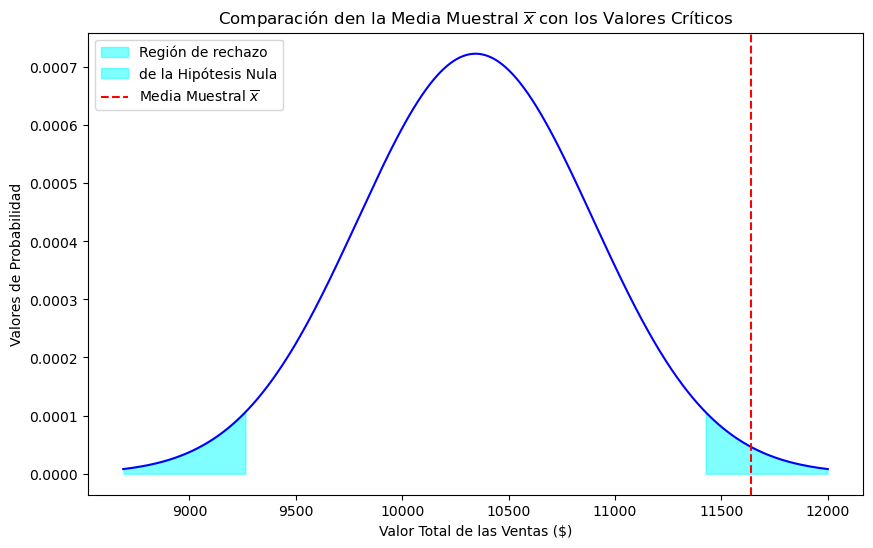

```python
# Importemos los paquetes necesarios para realizar las gráficas:
import numpy as np
import matplotlib.pyplot as plt
import seaborn as sns

# Creemos la distribución de datos de la Población:
x = np.linspace(media_poblacional - 3*desv_std, media_poblacional + 3*desv_std, 1000)
# Utilizamos Scipy para generar la distribución de probabilidad:
f_x = norm.pdf(x, media_poblacional, desv_std)

# Crear la gráfica:
plt.figure(figsize=(10, 6))
sns.lineplot(x=x, y=f_x, color='blue')

# Área bajo la curva entre 8690 y x_1:
x_fill_1 = np.linspace(8690, x_1, 2100)
y_fill_1 = norm.pdf(x_fill_1, media_poblacional, desv_std)
plt.fill_between(x_fill_1, y_fill_1, color='cyan', alpha=0.5, label='Región de rechazo')

# Área bajo la curva entre x_2 y 12000:
x_fill_2 = np.linspace(x_2, 12000, 2100)
y_fill_2 = norm.pdf(x_fill_2, media_poblacional, desv_std)
plt.fill_between(x_fill_2, y_fill_2, color='cyan', alpha=0.5, label='de la Hipótesis Nula')

# Agregemos una línea que establezca donde se encuentra la media muestral:
plt.axvline(media_muestral, color='red', linestyle='--', label=r'Media Muestral $\overline{x}$')

# Añadir las etiquetas y la leyenda
plt.legend()

# Insertando los correspondientes títulos:
plt.title(r'Comparación den la Media Muestral $\overline{x}$ con los Valores Críticos')
plt.xlabel('Valor Total de las Ventas ($)')
plt.ylabel('Valores de Probabilidad')

# Mostrar la gráfica:
plt.show()
```

## Método del $p$-Valor

A diferencia del método anterior, este busca calcular directamente la probabilidad de obtener la media muestral $\overline{x}$ dentro de la distribución de probabilidad de la media poblacional $\mu$ con desviación estándar $\sigma$. Esto dependerá del tipo de prueba en el que estemos. Si la prueba es unilateral, el $p$-valor corresponderá a su valor en la función acumulativa de probabilidad (CDF) con los parámetros poblacionales:

$$p=F(\overline{x};\mu,\sigma).$$

En el caso de las pruebas bilaterales, se determina el valor $p$ seleccionando el menor valor de la función (CDF) entre las dos colas. Estos pueden ser:
$$\begin{align}
p_1 &= F(\overline{x};\mu,\sigma),\\
p_2 &= 1-F(\overline{x};\mu,\sigma).
\end{align}$$

Luego, dado que dicha prueba debe tomar en cuenta la probabilidad dentro de un intervalo para representar las dos colas, se duplica dicho valor mínimo:
$$p=2\min(p_1,p_2)$$

Con lo cual obtendremos el valor $p$.

Dicho $p$-valor *no* es la probabilidad de que la hipótesis nula sea cierta bajo el resultado muestral, sino la probabilidad de obtener el resultado muestral dadon la hipótesis nula como cierta. Por lo cual, si dicho $p$-valor es mayor a la significancia estadística, se tendrá que aceptar; si en cambio, $p$ es menor a la significancia, entonces la hipótesis nula se rechazará. Para terminar con este método, basta decir que hoy en día es el más utilizado debido a que es el más fácilmente aplicable a software de cómputo.

### Ejemplo (Método del $p$-Valor):

En el caso que estamos siguiendo, al ser $\overline{x}$ mayor a $\mu$, por sentido común, el mínimo de los valores $p_1$ y $p_2$ debe ser $p_2$. Igualmente, incluso sin esta suposición, podremos realizar todo el método por medio de Python:

```python
# Utilizamos la función CDF para determinar p_1:
p_1 = norm.cdf(media_muestral, media_poblacional, desv_std)
p_2 = 1-norm.cdf(media_muestral, media_poblacional, desv_std)
# Calculamos p_2 y p por medio de la simetría:
p = 2*min(p_1,p_2)
print(f"El p-valor es de {round(p,4)}")

# Veríficamos si el p-valor es superior o inferior a la significancia para aceptar o negar H_0:
if p < Significancia:
 print("La hipótesis nula H_0 se puede rechazar.")
else:
 print("No se puede rechazar la hipótesis nula H_0.")
```

```
El p-valor es de 0.0189
La hipótesis nula H_0 se puede rechazar.
```

## Método de los Intervalos de Confianza

Este es un método similar al del valor crítico, solo que en este caso se creará un intervalo de confianza de $1-\text{significancia estadística}$ alrededor de la distribución normal estándar reescalada a la de la media muestral con la desviación estándar, y se determinará si la media poblacional de la hipótesis nula se encuentra dentro de dicho intervalo. Recordemos que esto se hace mediante la Unidad Tipificada o z-valores, por medio de la siguiente fórmula:

$$\text{Límites del Intervalo de Confianza}=\overline{x}\pm z\sigma$$

Al ser la versión estandarizada de la distribución normal de la que establecemos los valores críticos $z$, estos siempre serán los mismos. Para evitar cálculos innecesarios, se muestran en la *tabla de valores críticos de $z$ en pruebas con intervalos de confianza*:

$$\begin{array}{|c|c|c|}
\hline
\text{Nivel Sig.} & \text{Unilateral} & \text{Bilateral} \\
\hline
5\% & +1.645 (\text{o bien} -1.645) & \pm1.96 \\
\hline
1\% & +2.33 (\text{o bien} -2.33) & \pm2.58 \\
\hline
\end{array}$$

Nótese que este método es, en esencia, igual al del método de los valores críticos, solo que en vez de dejar igual la distribución de los datos y calcular los puntos críticos dada la significancia estadística, se reescala la distribución normal estándar a la media muestral junto con la desviación estándar, se toman los puntos críticos de la distribución normal estándar que ya conocemos de antemano para reajustarlos y, por último, se verifica si la media poblacional se encuentra dentro o fuera del intervalo de confianza. Dado el caso, aceptaremos o rechazaremos la hipótesis nula $H_0$ respectivamente.

También se podría realizar el proceso inverso, es decir, normalizar y comparar la media muestral con la media poblacional dentro de la propia distribución normal estándar. Esto se haría mediante la fórmula de los $z$-valores sin despejar que ya conocemos:

$$z_{\overline{x}}=\frac{\overline{x}-\mu}{\sigma}.$$

Cualquiera de los dos métodos es igualmente válido.

### Ejemplo (Método del Intervalo de Confianza):

Establezcamos los límites del intervalo de confianza en python y veamos si la media poblacional se encuentra dentro o fuera de ella:

```python
# Veamos los límites del intervalo de confianza re-escalados:
z_1 = media_muestral-(1.96)*desv_std
z_2 = media_muestral+(1.96)*desv_std
print(f"El intervalo de confianza del 95% es ({z_1},{z_2})")

# Verifiquemos si la media poblacional se encuentra dentro o fuera del intervalo:
if media_poblacional >= z_1 and media_poblacional <= z_2:
 print("Se puede aceptar la hipótesis nula H_0.")
else:
 print("Se puede rechazar la hipótesis nula H_0.")
```

```
El intervalo de confianza del 95% es (10559.08,12722.92)
Se puede rechazar la hipótesis nula H_0.
```

En la otra forma, al no necesitar redimensionar los puntos críticos, debemos comparar la media muestral $\overline{x}$ normalizandola:

```python
# Normalicemos la media muestral:
z_x = (media_muestral-media_poblacional)/desv_std
print(f"La media muestral normalizada es z_x = {round(z_x,4)}")

# Ahora verificamos si dicha media se encuentra dentro o fuera del rango estádar:
if z_x>=-1.96 and z_x<=1.96:
    print("Se puede aceptar la hipótesis nula.")
else:
    print("Se puede rechazar la hipótesis nula.")
```

```
La media muestral normalizada es z_x = 2.3478
Se puede rechazar la hipótesis nula.
```

Al igual que en el método del valor crítico, se puede mostrar gráficamente el resultado anterior. Sin embargo, en este caso esto se hace sobre la *distribución normal estándar*, nótese que es una evidencia clara de la similitud entre ambas pruebas:

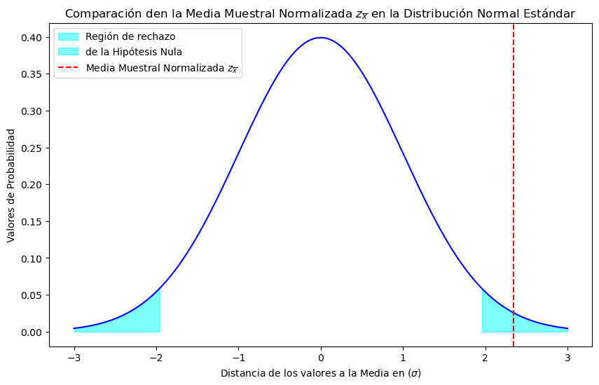

```python
# Gracias a la secuencialidad de comandos podremos utilizar las mismas variables re-valuandolas, para esta gráfica:

# Creemos la distribución de datos de la Población:
x = np.linspace(-3,3, 2000)
# Utilizamos Scipy para generar la distribución de probabilidad:
f_x = norm.pdf(x, 0, 1)

# Crear la gráfica:
plt.figure(figsize=(10, 6))
sns.lineplot(x=x, y=f_x, color='blue')

# Área bajo la curva entre -3 y x_1:
x_fill_1 = np.linspace(-3, -1.96, 2000)
y_fill_1 = norm.pdf(x_fill_1, 0, 1)
plt.fill_between(x_fill_1, y_fill_1, color='cyan', alpha=0.5, label='Región de rechazo')

# Área bajo la curva entre x_2 y 3:
x_fill_2 = np.linspace(1.96, 3, 2000)
y_fill_2 = norm.pdf(x_fill_2, 0, 1)
plt.fill_between(x_fill_2, y_fill_2, color='cyan', alpha=0.5, label='de la Hipótesis Nula')

# Agregemos una línea que establezca donde se encuentra la media muestral:
plt.axvline(z_x, color='red', linestyle='--', label=r'Media Muestral Normalizada $z_{\overline{x}}$')

# Añadir las etiquetas y la leyenda
plt.legend()

# Insertando los correspondientes títulos:
plt.title(r'Comparación den la Media Muestral Normalizada $z_{\overline{x}}$ en la Distribución Normal Estándar')
plt.xlabel(r'Distancia de los valores a la Media en ($\sigma$)')
plt.ylabel('Valores de Probabilidad')

# Mostrar la gráfica:
plt.show()
```

## Notas Finales

Después de realizar estos métodos, dependiendo del resultado, deberemos tomar una decisión. Como ya se mencionó, no podemos asegurar por completo que alguna de las hipótesis es absolutamente cierta. Sin embargo, si nuestras pruebas están bien hechas, es decir, si tomamos una muestra con el tamaño adecuado, que no estaba sesgada y cuyos datos se comportaban según una distribución normal, es poco probable que estos caigan en algún tipo de error. De cómo saber cuál debe ser dicho tamaño y cómo calcular los valores $\alpha$ y $\beta$ de los errores tipo I y II respectivamente, hablaré en un futuro artículo.

### Ejemplo (Toma de Decisión):

Dado que los tres métodos que aplicamos dieron como resultado que debemos rechazar la hipótesis nula, es razonable asumirlo. Así, podemos dar por verdadero que el resultado de la media muestral $\overline{x}$ no pudo surgir de forma puramente aleatoria de los datos poblacionales. Se llega a la conclusión de que la campaña de marketing tuvo, efectivamente, un efecto real en las ventas.

## Referencias

- Devore, Jay L. *Probabilidad y estadística para ingeniería y ciencias*. Novena edición, Pearson, 2011.
- Nield, Thomas.(2020).*Essential Math for Data Science*. O’Reilly Media.